# The FARSread Package

[figure not shown]

[figure not shown]

[figure not shown]

### The Fatality Analysis Reporting System (FARS) contains data derived from a census of fatal traffic crashes within the 50 States

[interactive chart not shown]

FARS was conceived, designed, and developed by the National Center for Statistics and Analysis (NCSA) of the National Highway Traffic Safety Administration in 1975:

- to provide an overall measure of highway safety,
- to help identify traffic safety problems,
- to suggest solutions, and
- to help provide an objective basis to evaluate the effectiveness of motor vehicle safety standards and highway safety programs.

### The FARSread package was created to make summary and visualization of the FARS data user-friendly in R

[interactive chart not shown]

The FARSread package has three functions:

- The fars_read function for reading the data in R
- The fars_summarize_years function for comparing monthly summaries
- The fars_map_state function to create a map plot where the accidents occurred

### In 2015 the the states with the highest number of accidents were Texas, California, and Florida

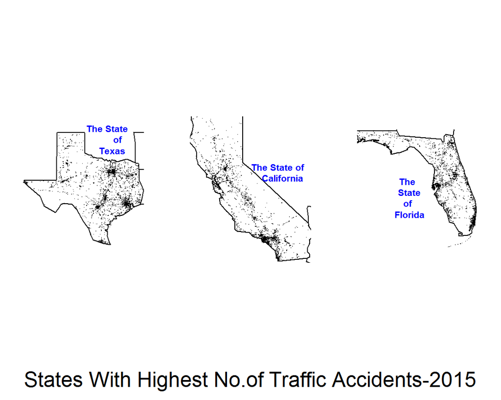

- Every dot on the map is a representation of where a traffic accident occured based on the latitude and longitudinal position reported in FARS data.
- The confluence of dots in certain areas indicate the location where traffic happened the most.

### The fars_map_state function makes it easy to visually illustrate the number of accidents in a particular state over years

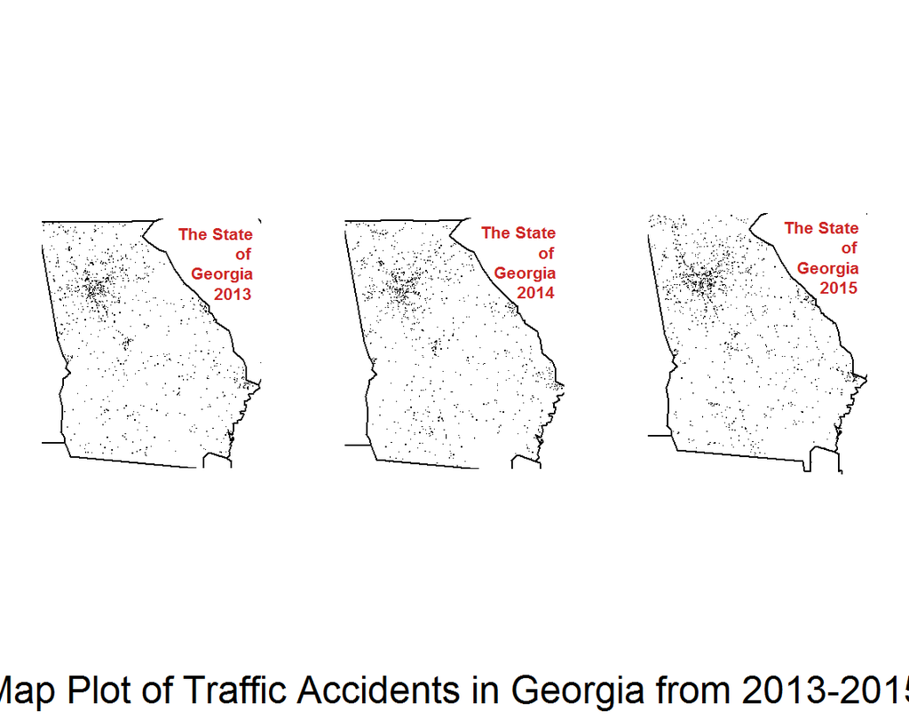

- Compared to numbers or tables, plots have the advantage of conveying more information at a glance.
- It also shows the the increase did not happen just in selected areas, but rather appears to have occured throughout the State.

### The fars_map_state allows for some features to be added on the map plot to improve readability by adding a few more information.

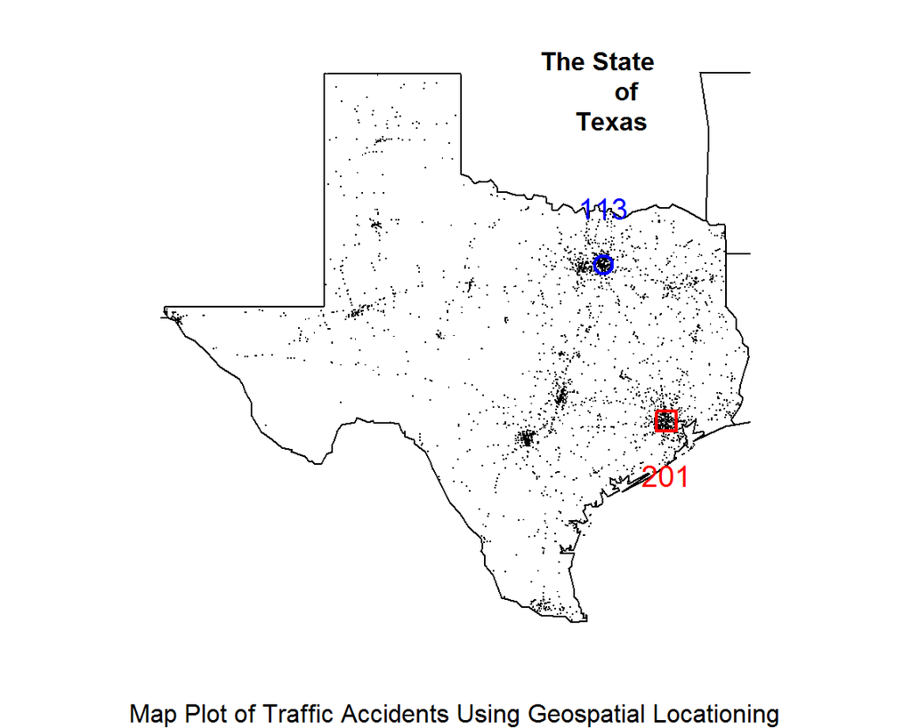

By providing features like:

- circles,
- squares,
- dots or even
- arrows,

we can add emphasis and improve how we convey information to our listeners during presentations.

### We can borrow from the package leaflet some functions to creatre an interactive plot

[interactive chart not shown]

An interactive map provides us with the flexibility to move the map around and to zoom in or out for greater details.

````r
---
title: "The FARSread Package"
output:
  flexdashboard::flex_dashboard:
    storyboard: true
    social: menu
    source: embed
---

```{r setup, include=FALSE}
library(flexdashboard)
library(FARSread)
library(dplyr)
library(tidyr)
library(ggplot2)
library(plotly)
library(leaflet)
```

### The Fatality Analysis Reporting System (FARS) contains data derived from a census of fatal traffic crashes within the 50 States


```{r}
comp_yrs <- fars_summarize_years(c(2013, 2014, 2015))
names(comp_yrs) <- c("month", "yr2013", "yr2014", "yr2015")
comp_yrs <- comp_yrs %>% mutate(month = as.factor(month.abb))
comp_yrs$month <- factor(comp_yrs$month, levels = c("Jan", "Feb", "Mar", "Apr", "May", "Jun", "Jul", "Aug", "Sep", "Oct", "Nov", "Dec"))
long_comp_yrs <- gather(comp_yrs, key = key, value = value, -month)
p <- ggplot(data = long_comp_yrs, aes(x = month, y = value, group = key, color = key)) + ### input the variables we want to plot
        geom_line(linetype = "dashed", size = 1) + ### show a line plot
        geom_point(size = 2, shape = 21) + ### show the points as well
        xlab("Month") + ### put a label on the x axis
        ggtitle("Number of Accidents Recorded per Month 2013-2015") ### Put a title
ggplotly(p)
```

***

FARS was conceived, designed, and developed by the National Center for Statistics and Analysis (NCSA) of the National Highway Traffic Safety Administration in 1975:

- to provide an overall measure of highway safety,

- to help identify traffic safety problems,

- to suggest solutions, and

- to help provide an objective basis to evaluate the effectiveness of motor vehicle safety standards and highway safety programs.

### The FARSread package was created to make summary and visualization of the  FARS data user-friendly in R

```{r}
accident_2015 <- fars_read("accident_2015.csv.bz2")
most_count <- accident_2015 %>% ###fars data object in R
        group_by(STATE) %>% ### groups the data according to State
        summarize(count = n()) %>% ### count the number of observations per State
        arrange(desc(count)) ### arrange from highest to lowest
plot_most_count <- most_count %>% ### The table above we just created
                        slice(1:15) %>% ### Get only top 15 States
                        mutate(STATE = c("TX", "CA", "FL", "GA", "NC", "PA","NY",
                                         "OH","IL", "SD", "MI", "TN", "AR", "MS",
                                         "AL")) %>% ### Change to State abb Names
                        as.data.frame() ### save as a data frame
plot_most_count$STATE <- factor(plot_most_count$STATE, levels = c("TX", "CA", "FL", "GA", "NC", "PA", "NY", "OH", "IL", "SD", "MI", "TN", "AR", "MS", "AL"))
g <- ggplot(plot_most_count, aes(STATE)) +
        geom_bar(aes(weight = count, fill = STATE)) +
        ggtitle("Top 15 States With Highest Number of Traffic Accidents in 2015")
ggplotly(g)
```

***

The FARSread package has three functions:

- The fars_read function for reading the data in R

- The fars_summarize_years function for comparing monthly summaries

- The fars_map_state function to create a map plot where the accidents occurred


### In 2015 the the states with the highest number of accidents were Texas, California, and Florida

```{r}
par(mfrow = c(1,3)) ### plot the map in three columns in a single row
par(oma = c(2, 0,0,0)) ### specify the margins to allow for titles and texts
par(mar=c(1,0.5,0.5,0.5)) ### specify the margins to fit the plot
fars_map_state(48, ### selects the number 48 which stands for the state of Texas
               2015) ### selects the year 2015
title("The State\n of\n Texas", ###text for title
      line=-2, ### position of the title
      cex.main = 1, ### size of the text
      adj = 0.8, ### left to right position of title
      col.main= "blue") ### color of the text

fars_map_state(6, ### selects the number 6 which stands for the state of California
               2015) ### selects the year 2015
title("The State of\n California", ###text for title
      line=-6, ### position of the title
      cex.main = 1, ### size of the text
      adj = 0.9, ### left to right position of title
      col.main= "blue") ### color of the text
mtext("States With Highest No.of Traffic Accidents-2015", ### title to print
      side = 1, ### print title on the bottom
      line = 0, ### start printin at line 0
      outer = TRUE, ### Use margins if available
      cex = 1.5) ### size of the text

fars_map_state(12, ### selects the number 12 which stands for the state of Florida
               2015) ### selects the year 2015
title("The\n State\n of\n Florida", ###text for title
      line=-8, ### position of the title
      adj = 0.4, ### left to right position of title
      cex.main = 1, ### size of the text
      col.main= "blue") ### color of the text
```

***

- Every dot on the map is a representation of where a traffic accident occured based on the latitude and longitudinal position reported in FARS data.

- The confluence of dots in certain areas indicate the location where traffic  happened the most.

### The fars_map_state function makes it easy to visually illustrate the number of accidents in a particular state over years

```{r}
par(mfrow = c(1,3)) ### plot the map in three columns in a single row
par(oma = c(2, 0,0,0)) ### specify the margins to allow for titles and texts
par(mar=c(1,0.5,0.5,0.5)) ### specify the margins to fit the plot
fars_map_state(13, ### selects the number 48 which stands for the state of Texas
               2013) ### selects the year 2015
title("The State\n of\n Georgia\n 2013", ###text for title
      line=-4, ### position of the title
      cex.main = 1, ### size of the text
      adj = 0.95, ### left to right position of title
      col.main= "firebrick3") ### color of the text

fars_map_state(13, ### selects the number 48 which stands for the state of Texas
               2014) ### selects the year 2015
title("The State\n of\n Georgia\n 2014", ###text for title
      line=-4, ### position of the title
      cex.main = 1, ### size of the text
      adj = 0.95, ### left to right position of title
      col.main= "firebrick3") ### color of the text
mtext("Map Plot of Traffic Accidents in Georgia from 2013-2015", ### title to print
      side = 1, ### print title on the bottom
      line = 0, ### start printin at line 0
      outer = TRUE, ### Use margins if available
      cex = 1.5) ### size of the text

fars_map_state(13, ### selects the number 48 which stands for the state of Texas
               2015) ### selects the year 2015
title("The State\n of\n Georgia\n 2015", ###text for title
      line=-4, ### position of the title
      cex.main = 1, ### size of the text
      adj = 0.95, ### left to right position of title
      col.main= "firebrick3") ### color of the text
```

***

- Compared to numbers or tables, plots have the advantage of conveying more information at a glance.

- It also shows the the increase did not happen just in selected areas, but rather appears to have occured throughout the State.

### The fars_map_state allows for some features to be added on the map plot to improve readability by adding a few more information.

```{r}
par(oma = c(1, 0,0,0)) ### specify the margins to allow for titles and texts
par(mar=c(0.5,0.5,0.5,0.5))
fars_map_state(48, ### selects the number 48 which stands for the state of Texas
               2015) ### selects the year 2015
points(x = -95.38142, y =  29.80174, col = "red", cex = 1.7, pch = 0, lwd = 2)
text(x = -95.38142, y =  29.80174, labels = "201", col = "red", cex = 1.2, pos = 1, offset = 1.5)
points(x = -96.79868, y =  32.80453, col = "blue", cex = 1.7, pch = 1, lwd = 2)
text(x = -96.79868, y =  32.80453, labels = "113", col = "blue", cex = 1.2, pos = 3, offset = 1.5)
title("The State\n of\n Texas", ###text for title
      line=-2, ### position of the title
      cex.main = 1, ### size of the text
      adj = 0.8, ### left to right position of title
      col.main= "black") ### color of the text
mtext("Map Plot of Traffic Accidents Using Geospatial Locationing", ### title to print
      side = 1, ### print title on the bottom
      line = 0, ### start printin at line 0
      outer = TRUE, ### Use margins if available
      cex = 1) ### size of the text
```

***

By providing features like:

- circles,

- squares,

- dots or even

- arrows,

we can add emphasis and improve how we convey information to our listeners during presentations.

### We can borrow from the package leaflet some functions to creatre an interactive plot

```{r}
leaflet() %>%
  addTiles() %>%
  addMarkers(lng=-95.38142, lat=29.80174, popup="Harris County.") %>%
  addMarkers(lng=-96.79868, lat=32.80453, popup="Dallas County.")
```

***

An interactive map provides us with the flexibility to move the map around and to zoom in or out for greater details.
````